# Homework 9

George Tapia (A20450857)

2023-05-01

### Part 2.1 (a)

#### (i)

#### We should remove the name before we do clustering since this value is unique,

#### it will not provide us with any useful insights

#### After looking at the dataset, I noticed that, top canines (C) and bottom canines (c)

#### had similar values. I double checked by using a correlation plot.

#### since the two attributes are highly correlated. If we use both of them, this can lead us

#### to less reliable statistical inferences so it is best to remove one.

#### I will remove the bottom canine attribute (random choice- both are similar)

#### (ii)

#### Given that all the features don’t have a significant difference, in terms of scale,

#### we do not need to standardize the data

#### (iii) (below, done through code)

```r
library(factoextra)
```

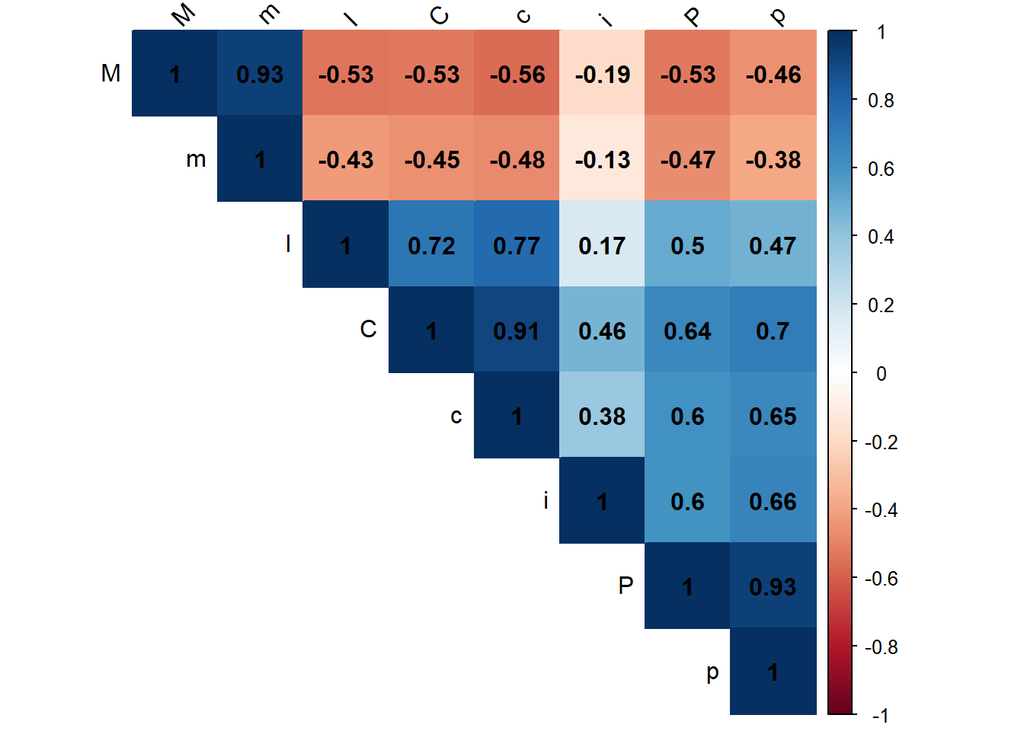

```r
library(corrplot)
working_directory <- getwd()
setwd(working_directory)
mammals_old <- read.table("file19.txt", header = TRUE, skip = 20)


# the tooth pattern
#
#(I) the number of top incisors,
#(i) bottom incisors,
#(C) top canines,
#(c) bottom canines,
#(P) top premolars,
#(p) bottom premolars,
#(M) top molars
#(m) bottom molars.

correlation_matrix <- cor(mammals_old[2:9])
corrplot(correlation_matrix, method = "color", type = "upper", order = "hclust", addCoef.col = "black", tl.col = "black", tl.srt = 45)
```

```r
mammals <- mammals_old[,-c(5)]
print(mammals)
```

```
##               Name I i C P p M m
## 1          Opossum 5 4 1 3 3 4 4
## 2  Hairy tail mole 3 3 1 4 4 3 3
## 3      Common mole 3 2 1 3 3 3 3
## 4   Star nose mole 3 3 1 4 4 3 3
## 5        Brown bat 2 3 1 3 3 3 3
## 6  Silver hair bat 2 3 1 2 3 3 3
## 7        Pigmy bat 2 3 1 2 2 3 3
## 8        House bat 2 3 1 1 2 3 3
## 9          Red bat 1 3 1 2 2 3 3
## 10       Hoary bat 1 3 1 2 2 3 3
## 11   Lump nose bat 2 3 1 2 3 3 3
## 12       Armadillo 0 0 0 0 0 8 8
## 13            Pika 2 1 0 2 2 3 3
## 14 Snowshoe rabbit 2 1 0 3 2 3 3
```

[output cut: 52 more lines]

### Part 2.1 (b) (REMOVED ATTRIBUTE - BOTTOM CANINES (c))

#### (i) Using the silhoutte method, we were able to determine that the

#### optimal number of clusters is 8. This means that each

#### number of cluster’s were evaluated to determine the number

#### that gave the best results, with respect to how well they were clustered.

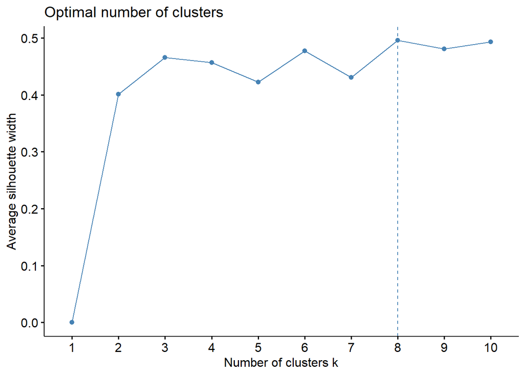

```r
fviz_nbclust(mammals[,-1], kmeans, method = "silhouette")
```

#### (ii)

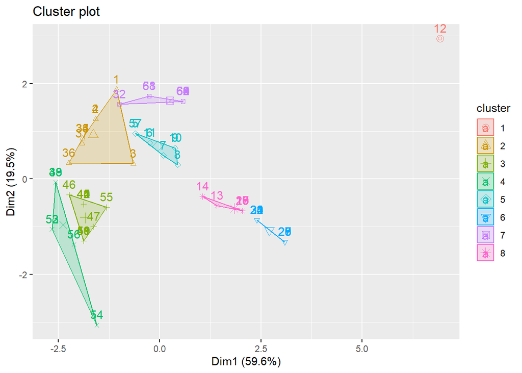

```r
km.mammals <- kmeans(mammals[,-1], 8, nstart = 10)
fviz_cluster(km.mammals, mammals[,-1])
```

#### (iii) 1, 9, 12, 7, 8, 11, 10, 8 (respectively)

```r
cluster_one <- mammals[which(km.mammals$cluster == 1),]
cluster_two <- mammals[which(km.mammals$cluster == 2),]
cluster_three <- mammals[which(km.mammals$cluster == 3),]
cluster_four <- mammals[which(km.mammals$cluster == 4),]
cluster_five <- mammals[which(km.mammals$cluster == 5),]
cluster_six <- mammals[which(km.mammals$cluster == 6),]
cluster_seven <- mammals[which(km.mammals$cluster == 7),]
cluster_eight <- mammals[which(km.mammals$cluster == 8),]

cat(" Number of observations in Cluster 1: ", nrow(cluster_one), "\n",
    "Number of observations in Cluster 2: ", nrow(cluster_two), "\n",
    "Number of observations in Cluster 3: ", nrow(cluster_three), "\n",
    "Number of observations in Cluster 4: ", nrow(cluster_four), "\n",
    "Number of observations in Cluster 5: ", nrow(cluster_five), "\n",
    "Number of observations in Cluster 6: ", nrow(cluster_six), "\n",
    "Number of observations in Cluster 7: ", nrow(cluster_seven), "\n",
    "Number of observations in Cluster 8: ", nrow(cluster_eight), "\n")
```

```
##  Number of observations in Cluster 1:  1
##  Number of observations in Cluster 2:  9
##  Number of observations in Cluster 3:  12
##  Number of observations in Cluster 4:  7
##  Number of observations in Cluster 5:  8
##  Number of observations in Cluster 6:  11
##  Number of observations in Cluster 7:  10
##  Number of observations in Cluster 8:  8
```

```r
km.mammals <- kmeans(mammals[,-1], 8, nstart = 10)
print("Total SSE:")
```

```
## [1] "Total SSE:"
```

```r
print(km.mammals$totss)
```

```
## [1] 551.9394
```

```r
print(km.mammals)
```

```
## K-means clustering with 8 clusters of sizes 9, 10, 9, 18, 4, 11, 4, 1
##
## Cluster means:
##          I        i         C        P         p        M        m
## 1 1.777778 2.777778 0.8888889 2.222222 2.4444444 3.000000 3.000000
## 2 0.100000 3.900000 0.3000000 3.100000 3.1000000 3.000000 3.000000
## 3 3.222222 3.000000 1.0000000 3.777778 3.7777778 2.666667 2.888889
## 4 1.055556 1.000000 0.0000000 1.111111 0.7777778 3.000000 3.000000
## 5 2.250000 1.250000 1.0000000 3.750000 3.7500000 0.750000 0.750000
## 6 3.000000 2.818182 1.0000000 3.363636 3.2727273 1.090909 2.000000
## 7 3.000000 3.000000 1.0000000 3.000000 2.0000000 1.000000 1.000000
## 8 0.000000 0.000000 0.0000000 0.000000 0.0000000 8.000000 8.000000
##
## Clustering vector:
##  [1] 3 3 3 3 1 1 1 1 1 1 1 8 4 1 4 4 4 4 4 4 4 4 4 4 4 4 4 4 4 4 4 2 3 3 3 3 3 6
## [39] 6 6 6 6 6 6 6 6 6 7 7 7 7 5 5 5 6 5 1 2 2 2 2 2 2 2 2 2
##
## Within cluster sum of squares by cluster:
## [1] 11.777778  5.700000 15.555556 17.833333  8.500000  7.272727  0.000000
## [8]  0.000000
##  (between_SS / total_SS =  87.9 %)
##
## Available components:
##
## [1] "cluster"      "centers"      "totss"        "withinss"     "tot.withinss"
## [6] "betweenss"    "size"         "iter"         "ifault"
```

#### (vi)

#### Cluster 1: Only one animal so can’t really deduce anything from this cluster yet.

#### However, armadillos have no canines, after research, so it can be meaningful.

```r
print(cluster_one[, 1])
```

```
## [1] "Armadillo"
```

#### Cluster 2: All of these animals are ugly and creepy, except for the bear.

#### All share a similar characteristic. They all have a lot of fur.

```r
print(cluster_two[, 1])
```

```
## [1] "Opossum"         "Hairy tail mole" "Common mole"     "Star nose mole"
## [5] "Wolf"            "Fox"             "Bear"            "Civet cat"
## [9] "Raccoon"
```

#### Cluster 3: Several of these animals are fast, and use their senses to hunt their prey

```r
print(cluster_three[, 1])
```

```
##  [1] "Weasel"      "Mink"        "Ferrer"      "Badger"      "Skunk"
##  [6] "River otter" "Sea otter"   "Jaguar"      "Ocelot"      "Cougar"
## [11] "Lynx"        "Grey seal"
```

#### Cluster 4: martens, fishers, and wolverines are predators that feed on smaller mammals and bird,

#### while fur seals, sea lions, walruses, and elephant seals primarily consume fish

#### and other marine animals. This cluster is meh.

```r
print(cluster_four[, 1])
```

```
## [1] "Marten"        "Fisher"        "Wolverine"     "Fur seal"
## [5] "Sea lion"      "Walrus"        "Elephant seal"
```

#### Cluster 5: most of these animals are bats so this is a great grouping

```r
print(cluster_five[, 1])
```

```
## [1] "Brown bat"       "Silver hair bat" "Pigmy bat"       "House bat"
## [5] "Red bat"         "Hoary bat"       "Lump nose bat"   "Peccary"
```

#### Cluster 6: The majority of these animals are rodents so this is a good cluster as well

```r
print(cluster_six[, 1])
```

```
##  [1] "Gray squirrel" "Fox squirrel"  "Pocket gopher" "Kangaroo rat"
##  [5] "Pack rat"      "Field mouse"   "Muskrat"       "Black rat"
##  [9] "House mouse"   "Porcupine"     "Guinea pig"
```

#### Cluster 7: All of the animals, except one, are Ungulates.

#### Ungulates are characterized by their hooved feet, which typically have an even or odd number of toes.

#### Coyotes are not ungulates, but they share a common habitat with many ungulates.

#### Great grouping!

```r
print(cluster_seven[, 1])
```

```
##  [1] "Coyote"         "Elk"            "Deer"           "Moose"
##  [5] "Reindeer"       "Antelope"       "Bison"          "Mountain goat"
##  [9] "Musk ox"        "Mountain sheep"
```

#### Cluster 8: Most of these are rodents so this is a good grouping as well

```r
print(cluster_eight[, 1])
```

```
## [1] "Pika"            "Snowshoe rabbit" "Beaver"          "Marmot"
## [5] "Groundhog"       "Prairie Dog"     "Ground Squirrel" "Chipmunk"
```

#### In summary, Cluster 1 consists of a single animal, the armadillo, which is notable for its lack of

#### canines, making it an interesting case. Cluster 2 is made up of animals with abundant fur, although they

#### vary in species and are subjectively seen as “ugly and creepy” with the exception of the bear. Cluster 3

#### contains several swift animals that rely on their senses while hunting. Cluster 4 encompasses both land

#### predators and marine mammals. Cluster 5 predominantly includes bats,

#### demonstrating a cohesive grouping. Clusters 6 and 8 mostly consist of rodents, indicating appropriate

#### groupings. Cluster 7 is largely made up of ungulates, with the exception of the coyote, which inhabits

#### similar environments as many ungulates. Overall, great findings!

### Part 2.2

#### (a) I looked at the dataset. Since I can’t tell what the attributes are, it would be best

#### to scale the data to prevent any distortion.

```r
library(dbscan)
library(fpc)
s1 <- read.csv("s1.csv", header = TRUE)
s1.scaled <- scale(s1)
```

#### (b)(i - ii)

#### I see 15 notable clusters from the chart. Though, all of them are not well seperated (only one).

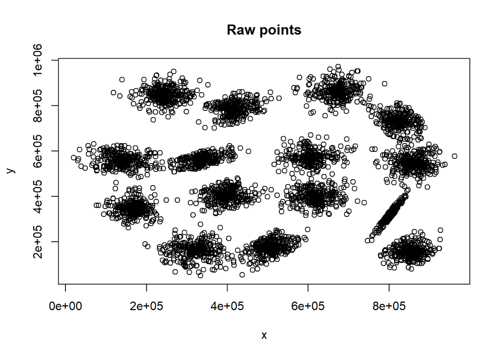

```r
plot(s1, main="Raw points")
```

#### (c)(i - iii)

#### I would only used 15 clusters since the plot “Raw points” shows 15 distinguishable clusters.

#### The plot shows me that 15 clusters will be a good classification pattern to analyze for insights.

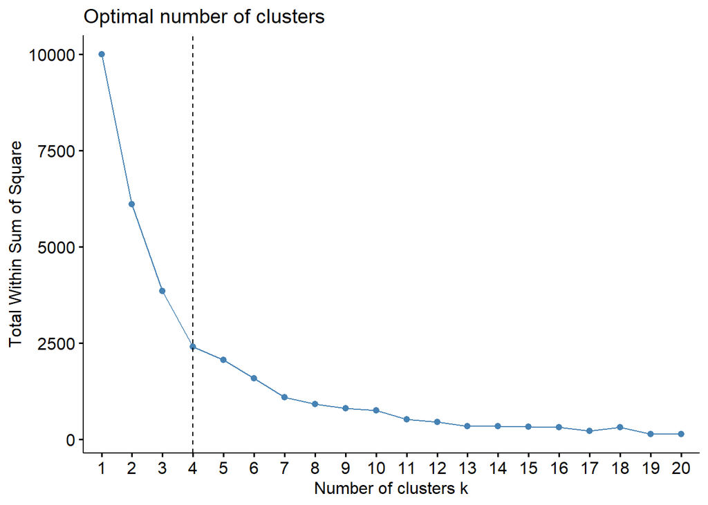

```r
fviz_nbclust(s1.scaled, kmeans, method = "wss", k.max = 20)  + geom_vline(xintercept = 4, linetype = 2)
```

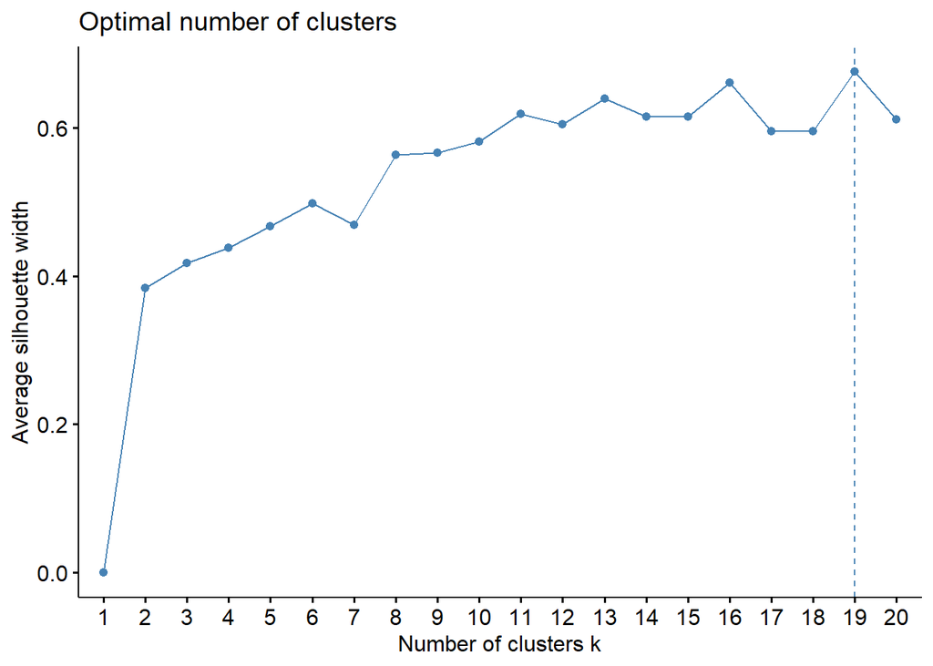

```r
fviz_nbclust(s1.scaled, kmeans, method = "silhouette", k.max = 20)
```

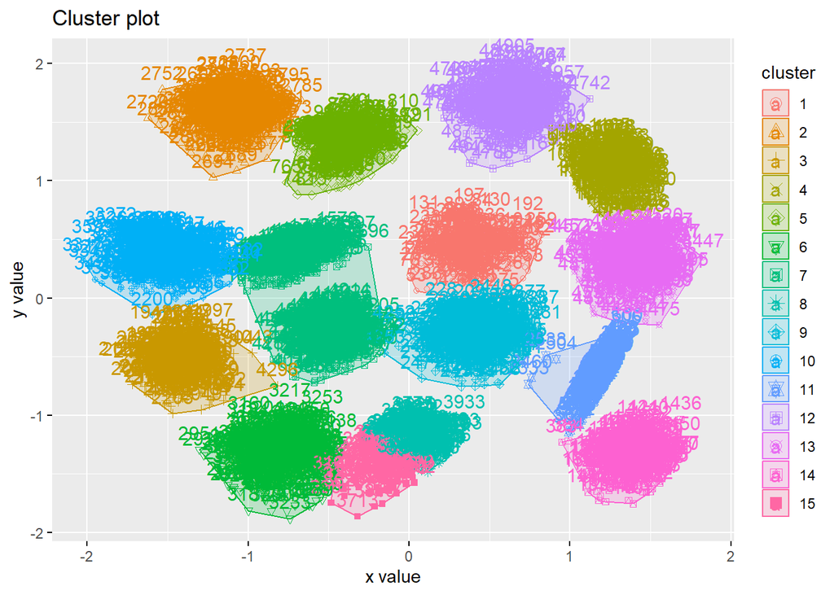

```r
km.s1.scaled <- kmeans(s1.scaled, 15, nstart = 10)
fviz_cluster(km.s1.scaled, s1)
```

#### (e)

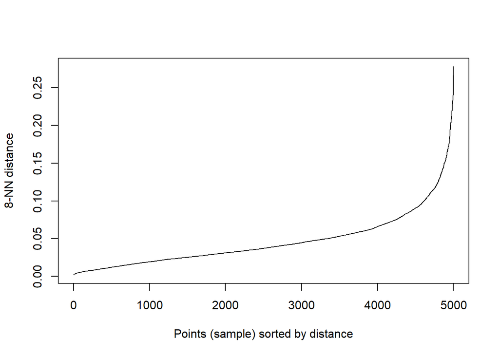

```r
kNNdistplot(s1.scaled, k = 8)
```

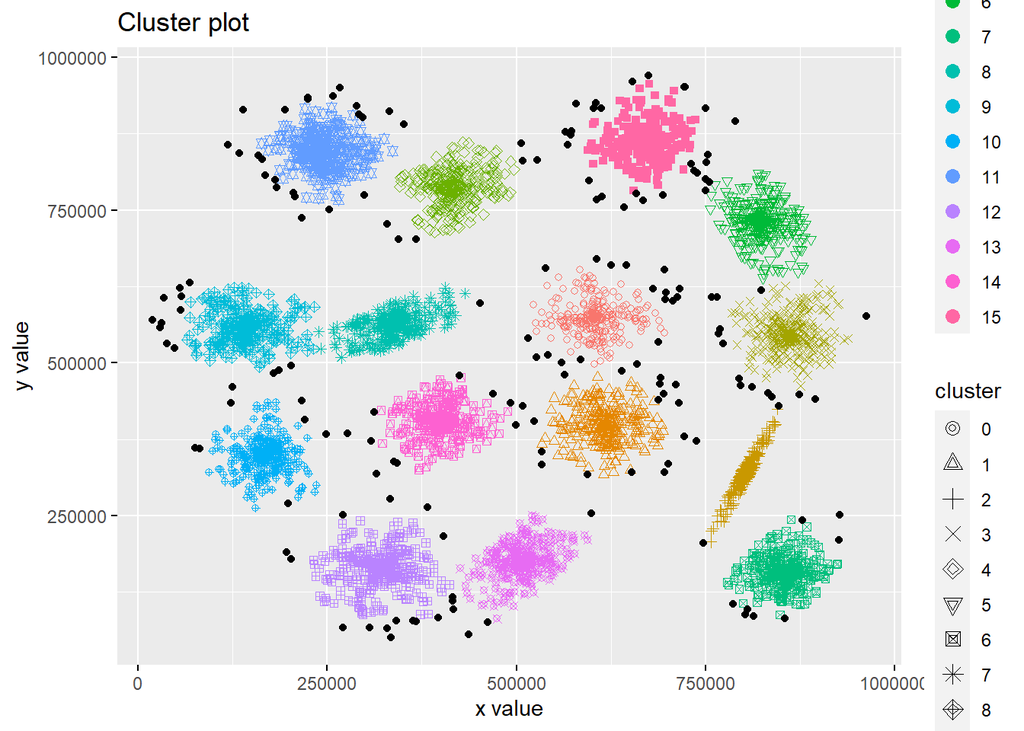

```r
dbscan.s1.scaled <- fpc::dbscan(s1.scaled, eps = 0.095, MinPts = 8)
fviz_cluster(dbscan.s1.scaled, s1, stand = FALSE, ellipse = F, geom = "point")
```

#### (i)

#### a value of 8 would be best becuase the clusters look more dense.

#### (ii)

#### At minPts = 8, eps = 0.095, there are 15 clusters.